# Private Federated Aggregation of LLM-Agent Memory

### Usable Shared Memory with a Measurable Leakage-Drop Guarantee under Secure Aggregation and the Skellam Mechanism

## Abstract

LLM agents increasingly accumulate **per-user memory**, distilled notes, preferences, and skill embeddings (as in A-MEM and Mem0), that make them personal and effective. Pooling these memories *across users* would give a fleet of agents a shared **routing prior** over what the fleet collectively knows, but the memory objects are exactly the sensitive artifact: recent extraction (MEXTRA) and membership-inference (MRMMIA) attacks recover verbatim user facts from agent memory. We ask whether a shared memory pool can be made **useful and provably private at once**.

We aggregate per-user memory-note embeddings into a shared, bucketed **centroid memory** under **Secure Aggregation (SecAgg)** composed with the **discrete Skellam mechanism**, so the pooled memory carries a single central differential-privacy guarantee with **no trusted curator** and **no individual note in the clear**. The payload is new but the cryptographic path is verbatim prior work, which lets us reuse a rigorous discrete-DP accountant. We evaluate on **LongMemEval** (real long-horizon conversational memory) and on **LLM-distilled A-MEM/Mem0-style notes** — and we insist throughout that utility and leakage be read **at the same operating point**, a discipline that turns out to be load-bearing.

Four findings.

**(1) A joint frontier, usable and safe at one operating point.** We measure both axes at *every* fidelity `K` — which a two-axis claim requires, and which our own superseded draft did not do (it reported utility only at `K≤256` and leakage only at `K≥512`, so its two headline numbers described disjoint releases). On the frontier the coarse-`K` regime is usable **and** safe together: at `K=32` the pool retains **95% of clean evidence-recall at ε≈9.3** (0.428 → 0.406, against 0.156 chance) while a calibrated offline-LiRA attack falls from **AUC 0.833 / TPR@1%FPR 0.175 (17× the floor) to the 1% false-positive floor (0.011)**, and reconstruction-decode from 0.771 to 0.396. At `K=128` (72% retention) *both* attacks reach their floor. The privacy axis is **flat in `K`** — DP defeats the calibrated attack at every fidelity — so `K` is chosen on utility alone (§7.1).

**(2) The weak attack everyone reaches for is blind exactly where you would deploy.** The uncalibrated cosine proxy used by prior agent-memory work reads **0.504 — chance — at `K=32`**, on the very clean release the calibrated attack breaks at AUC 0.833 with 77% note reconstruction. A proxy-only evaluation would therefore have certified a leaking pool as safe, and would have concluded (as our superseded draft did) that leakage is a sparse-regime curiosity rather than a property of the pool one would actually ship. The endpoint is real; the proxy could not see it (§7.5). The **published MEXTRA/MRMMIA attacks against a live agent** succeed on a raw-text memory (recovery 1.0, AUC 0.98) yet recover **nothing** against our centroid release (§7.10).

**(4) A memory is re-aggregated, not released once, so the budget must compose.** Naive repeated release destroys the guarantee: a month of daily re-aggregation at the single-shot σ costs **ε≈93, not 9.3**. But the required noise grows only as **√T**, so a cadence can be *bought* up front — a **monthly re-aggregation sustained for a full year fits inside the same ε≈9.3 at 81% retention** (§5.7). We further show the discrete mechanism is **privacy-free at our quantiser resolution** and that a **vector-only release dominates** the natural two-channel design (identical utility, ~1.5× tighter ε). Counter-intuitively, **LLM-distilled notes leak *more* than raw turns** (distillation concentrates identifying facts), yet DP collapses both to chance, so the realistic payload *strengthens* the case.

## 1. Introduction

**Agent memory is the new sensitive payload.** Production LLM-agent frameworks (A-MEM, Mem0) persist a per-user store of distilled notes: "the user is allergic to penicillin," "prefers metric units," "is migrating a Postgres 14 cluster." This memory is what makes an agent personal, and it is also a dense concentrate of personally identifying information. A natural, high-value idea is to **share memory across users**, so that a fleet of agents can profit from what the fleet collectively knows. But naïvely pooling raw notes is a privacy disaster, and recent work shows the threat is concrete, not hypothetical: **MEXTRA** [11] extracts verbatim memory content and **MRMMIA** [12] performs membership inference against agent memory with high success.

**What a private pool can and cannot be: a routing prior, not a note exchange.** We are precise about the object we release, because it bounds what may honestly be claimed for it. The shared pool is `K` *centroid vectors* and **no text**. A receiving agent therefore cannot read another user's note out of it, and we do not claim it can: verbatim knowledge transfer across users is *not* what this mechanism delivers, and any mechanism that did deliver it would be releasing the very artifact the attacks of §2 consume. What the pool *does* deliver is a **shared routing prior**: a fleet-level map of *which regions of memory space hold knowledge*, against which any agent can route a query — to the right local memory, the right tool, the right public corpus — without any note leaving its device. That is a narrower promise than "every agent inherits every fix," and it is the one our metric actually measures (evidence-recall: did the query reach the bucket containing its evidence?). It is also the promise worth keeping: the coarse pool is exactly the part of shared memory that *can* be released under a guarantee, and §7.1 shows it is released nearly for free.

**Why the obvious defenses are insufficient.** Access-control layers (*Collaborative Memory* [13]) and on-device masking (*MemPrivacy* [14]) restrict *who* sees a note but provide no formal guarantee over the *aggregate*, and a curated central datastore [15] reintroduces a trusted party. What is missing is a mechanism that (a) needs **no trusted curator**, (b) gives a **central-DP guarantee over the shared pool**, and (c) is shown to actually **degrade the known attacks** while keeping the pool useful.

**Our approach.** We treat federated memory aggregation as a **secure summation of per-user bucketed embeddings**. Each user projects their notes to a working dimension `d` with a **public-seed random projection**, maps them into `K` shared buckets (random-hyperplane LSH), forms a per-bucket sum-vector, and contributes it through **SecAgg** [2] so the server sees only the masked sum; the **Skellam mechanism** [5] adds calibrated discrete noise that **composes under summation**, yielding a single distributed-DP guarantee on the pooled centroid memory. Retrieval is cosine lookup against the noised centroids. The cryptographic path is used **verbatim** from federated discrete-DP work; the novelty is the *payload* (agent-memory embeddings) and the *evaluation* (a measured attack-success drop).

**Why this payload, and why now.** Federated DP for LLM *adaptation* (DP-LoRA, prompt tuning) is saturated, and recent federated-privacy work for LLMs targets *other* objects, DP synthetic-data generation (POPri [16]) and privacy-constrained agent self-evolution (Fed-SE [17]), rather than the aggregation of a shared **memory** pool; contemporaneous agent-memory security surveys [18] catalogue attacks and access-control/redaction defenses but no curator-free DP aggregation mechanism. The nearest mechanism, *DP Datastore Generation* [15], privatises a retrieval datastore but in a **centralized, single-curator** setting with generic additive noise and no secure aggregation (§2). Federated agent-*memory* aggregation under SecAgg + discrete Skellam DP is thus an open seam. Crucially, agent-memory objects are **genuinely tiny-dimensional and often already discrete**, which is exactly the regime where the discrete Skellam mechanism is most efficient and where our dimension analysis is most credible.

**Contributions.**

1. **A federated agent-memory aggregation mechanism** that composes SecAgg with the Skellam mechanism over bucketed memory-note embeddings, giving a curator-free central-DP shared **routing prior** (§4–5).
2. **A joint utility/leakage frontier, and a positive endpoint on it.** We measure both axes **at every fidelity `K`**, which a two-axis claim requires and which our own superseded draft did not do (it reported utility only at `K≤256` and leakage only at `K≥512`, so its two headline numbers described disjoint releases). On the frontier the coarse-`K` regime is usable *and* safe at one operating point: at `K=32` the pool retains **95% of clean evidence-recall** at ε≈9.3 while a calibrated offline-LiRA attack falls from **AUC 0.833 / TPR@1%FPR 0.175** to the **1% false-positive floor** (0.011), and reconstruction-decode from 0.771 to 0.396; at `K=128` (72% retention) *both* attacks reach their floor (§7.1).
3. **A methodological result: the weak attack the literature defaults to is blind exactly where it matters.** The uncalibrated cosine proxy reads **0.504 — chance — at `K=32`**, on the same clean release the calibrated attack breaks at AUC 0.833. A proxy-only evaluation would therefore have certified a leaking pool as safe, and would have reported (as our superseded draft did) that leakage only exists in a sparse regime nobody would deploy. The endpoint is real; the proxy could not see it (§7.5).
4. **A negative result with teeth: the dimension "crossover" is an artifact of data-dependent preprocessing.** Fitting the projection on user notes is an unaccounted release *and* it fabricates the finding that tiny-`d` is jointly optimal for privacy and utility. Under a data-independent projection the effect reverses on the utility axis and vanishes on the leakage axis, with an identity-projection control (`d=384`) that all three projections must and do agree on (§7.4). We believe this confound is not specific to this paper.
5. **An end-to-end-accounted mechanism, including repeated release**: the projection, the LSH anchors, the clip bound `C` and the quantiser bound `B := C` are all public or DP-selected, so the reported ε covers the entire pipeline rather than only its last stage (§5.2, §7.7); the clip-selection cost is 0.2% of the budget. Because agent memory is *re-aggregated* as users write notes, we also account for the `T`-round release a deployment actually performs: naive re-release is ruinous (ε 9.3 → 93 for a month of daily rounds), but the cost is **√T** in the noise scale, so a **monthly cadence sustained for a year fits inside the same ε≈9.3 at 81% retention** (§5.7).
6. **A rigorous, tightened accounting**: an exact Skellam-RDP ε for the discrete mechanism (Agarwal et al. Thm 3.5 [5]), a proof that **discretisation is free** at our resolution, and a **vector-only release** that dominates the two-channel design once bucket occupancy is accounted for (§5.3, §7.7, §7.11).
7. **A realistic-payload validation**: LLM-distilled A-MEM/Mem0-style notes leak *more* than raw turns, yet DP still collapses the attack to chance: the real payload strengthens, not weakens, the result (§7.6).

All results are reported as **5-seed means with final (not peak) metrics**; the harness and grid are released (§10).

## 2. Related Work

**Federated DP with secure aggregation and discrete noise.** SecAgg [2] lets a server compute a sum of client vectors without seeing any summand. To obtain a DP guarantee that composes under that sum without a trusted curator, discrete mechanisms are used: the **distributed discrete Gaussian** [6] and the **Skellam mechanism** [5], the latter being closed under addition (the sum of Skellams is Skellam) and efficient at low bit-width. Prior deployments target **gradient** payloads for model training. We reuse this path *verbatim* but change the payload to **agent-memory embeddings** and the objective to **retrieval**, not learning.

**Privacy of LLM-agent memory.** Agent frameworks A-MEM [9] and Mem0 [10] persist distilled per-user memories. Their privacy is under active attack: **MEXTRA** [11] extracts memory content and **MRMMIA** [12] runs membership inference; a memory-security survey [18] catalogues this attack literature. Defenses so far are **access control** (*Collaborative Memory* [13], which also introduces a shared-vs-private memory split but governs *who reads* a note, not the aggregate) and **on-device masking / redaction** (*MemPrivacy* [14]); neither gives an aggregate formal guarantee. We therefore **cite and reuse the attacks as our evaluation harness** rather than claiming them, and provide the missing mechanism-side guarantee.

**Federated retrieval / datastores (the nearest prior art).** *DP Datastore Generation* [15] is the closest existing mechanism: it partitions data with **locality-sensitive hashing** and adds **calibrated DP noise to each bucket's aggregate**, releasing a private datastore on which membership-inference accuracy falls to near-chance (≈53.6% at ε=5), the same LSH-bucket-plus-DP skeleton and privacy-endpoint framing we adopt. It is, however, **centralized and single-curator**, uses **generic additive (continuous) noise with no secure aggregation**, and its payload is a **classification/retrieval datastore**, not cross-user agent memory. Our delta is therefore fourfold: (i) a **federated, curator-free** release under **SecAgg**, where the noise is added distributively and no party ever sees a summand; (ii) the **Skellam** mechanism, whose **closure under summation** is precisely what makes the distributed release *equal* the intended central mechanism (a discrete-Gaussian/continuous-noise datastore does not compose this way under modular SecAgg); (iii) the **agent-memory embedding** payload and cosine-retrieval objective; and (iv) the coupled **dimension/density crossover** and the distilled-payload finding (§7.2, §7.4). **POPri** [16] is federated and private but produces **DP synthetic data via preference optimisation**, not an aggregated memory/preference pool, so it is orthogonal; **Fed-SE** [17] federates agent *self-evolution* under privacy constraints, adapting behaviour, not releasing a shared memory. To our knowledge no prior work aggregates cross-user agent memory under SecAgg + discrete-DP with a measured attack-drop endpoint.

**Dimension dependence of DP.** That utility degrades with dimension under DP is classical (Bassily–Smith–Thakurta [20]) and was sharpened for deep models by Chen et al. [19]. We do **not** claim the dimension dependence itself; our contribution is the **coupled crossover** (that in agent memory, dimension governs pre-DP *leakage* and DP *utility-retention simultaneously*, making tiny-d a joint optimum) and the demonstration on real memory embeddings.

## 3. Threat Model and Problem Setup

**Parties.** `N` users, each with a local agent holding a set of memory notes; an honest-but-curious aggregation server; and downstream agents that query the shared memory.

**Goal.** Produce a single **shared memory pool** (a set of `K` centroid embeddings) that any agent can query by cosine similarity to retrieve relevant knowledge contributed by the fleet, such that the pool carries a **central (ε, δ)-DP guarantee at user granularity** and no individual user's notes can be reconstructed or their membership inferred.

**Trust / adversary.** No trusted curator: under SecAgg the server observes only the masked sum, so the DP noise need not be added by a trusted party. The adversary is a recipient of the released pool (server or any downstream agent). It mounts:

- **Membership inference (MRMMIA analog):** given a candidate note embedding `x`, decide whether the user who owns `x` contributed to the pool. Score `s(x) = cos(x, centroid[bucket(x)])`; members pulled their own centroid and score higher. Metric: ROC-AUC (0.5 = no leakage).
- **Extraction (MEXTRA analog):** advantage in reconstructing an in-bucket member embedding from the centroid; we report the member/non-member **extraction gap**.

**The vulnerable subpopulation.** In a *sum* mechanism, leakage concentrates where **few users contribute to a bucket**: averaging already protects well-populated buckets, and distributed-DP noise is *most* protective exactly at the sparse tail. We therefore stratify every leakage metric by the **low-count tail** (buckets with ≤ 3 contributors), which is the honest worst case and the group agent-memory privacy actually cares about (rare/unique notes).

**Threat boundary (what we do not defend).** Our adversary is **passive**: a recipient of the released pool — the honest-but-curious server, or any downstream agent — and, under SecAgg, an observer of masked traffic. Two adversaries are explicitly out of scope. (i) **Active, colluding clients.** A malicious participant can inject structured notes to steer particular bucket centroids across epochs, and query the pool before and after a target user joins, turning the offline LiRA of §7.8 into an *adaptive online* attack against specific delta vectors. Robust aggregation against poisoning of a private vector-retrieval pool is an open problem, orthogonal to the release mechanism analysed here. (ii) **Participation metadata.** SecAgg hides a client's *contents*, not the fact that it participated; §5 specifies mandatory participation with padded dummy payloads to close that channel, an assumption we state but do not measure.

**Utility.** For a query `q`, retrieval routes to the top-`k` centroids by cosine; utility is whether the *right* content is retrieved (evidence-recall / answer-recall on real benchmarks, topic-accuracy on synthetic corpora).

## 4. Bucketed Centroid Memory

Let each note `i` of user `u` have embedding `e_i ∈ R^D` from a sentence encoder. We reduce to a working dimension `d` with a **public-seed Gaussian random projection** `P ∈ R^{D×d}`, `P_{jk} ~ N(0, 1/d)`, L2-normalize, and assign to one of `K` buckets by random-hyperplane LSH: fix `K` random anchors `a_1..a_K` and set `bucket(i) = argmax_k ⟨e_i, a_k⟩`. Both `P` and the anchors are drawn from a **published seed and never touch user data**, so shipping them to clients releases nothing and the ε of §5.4 accounts for the *entire* pipeline. This is not a detail: a PCA fit on the users' notes — the obvious choice, and the one an earlier draft made — is a data-dependent release whose privacy cost is unaccounted, and §7.2 shows it also manufactures a spurious finding. Each user forms, per bucket `k`, a **sum-vector** `v_u[k] = Σ_{i: bucket(i)=k} e_i` and a **count** `c_u[k]`. The (non-private) shared centroid is

$$ \mu[k] \;=\; \mathrm{normalize}\!\Big( \tfrac{\sum_u v_u[k]}{\sum_u c_u[k]} \Big). $$

Retrieval for query `q` returns the top-`k` buckets by `cos(q, \mu[k])`. `K` controls memory *fidelity* (more buckets = finer memory), `d` controls embedding *resolution*; both, as we show, trade off against privacy.

## 5. Private Release: SecAgg + Skellam

**Per-user clipping and quantisation.** A user's contribution to the release is not one bucket but the *whole* payload: the concatenation `V_u = [v_u[1]; …; v_u[K]] ∈ R^{K·d}`. We therefore clip `V_u` **globally**, to a single L2 bound `C`, and only then quantise to integers on a fixed grid of resolution `s = range_max / B` (`range_max = 1e6`, `B` the quantiser bound). This yields integer vectors amenable to SecAgg and to a discrete noise mechanism, with **user-level L2 sensitivity exactly `Δ_2 = C · s`**.

**Neighbouring relation.** Throughout, two datasets are neighbours if one is obtained from the other by **adding or removing a single user** (unbounded DP). This is what makes `Δ_2 = C·s` exact: deleting a user removes one clipped payload of norm ≤ `C`. (Under the *replace-one* convention the same mechanism would have `Δ_2 = 2C·s`, and every ε below would double.) We use the same relation for the clip-selection mechanism of §5.2, so the two costs compose against a single definition.

### 5.2 The clip bound is a mechanism parameter, so it must be public too

`C` and `B` are shipped to every client. The natural choice — `C` = the 95th percentile of the observed payload norms, `B` = the largest observed coordinate — is a **function of the private corpus**, so releasing it is an unaccounted release, exactly the error §7.2 diagnoses for the projection. An earlier draft of this paper made both. We fix both, and neither is expensive.

- **`B := C` is free.** Since every note is L2-unit and the payload is clipped first, `|V_u[j]| ≤ ‖V_u‖_2 ≤ C` for every coordinate `j`. So `B := C` is a *public* bound that provably never clips a coordinate, and ε is invariant to `B` anyway: `Δ_2/√μ = 1/σ` regardless of `s = range_max/B`. Nothing is paid.
- **`C` is DP-selected.** We choose `C` from a public geometric grid with the **exponential mechanism** on the rank utility `u(c) = −|#{u : ‖V_u‖₂ ≤ c} − q·N|`, `q = 0.95`, sampling `c` with probability `∝ exp(ε_c·u(c)/2)`. Its sensitivity under **add/remove** deserves care, because the count *and* the target `q·N` both move when a user leaves. Removing a user whose norm is `≤ c` drops the count by 1 and the target by `q`, so the argument of `|·|` shifts by only `1 − q = 0.05`; removing a user whose norm is `> c` leaves the count alone and shifts the target by `q`. Hence

  `Δu = max(1 − q, q) = q = 0.95 ≤ 1`,

  and the sampler above — which would be `ε_c`-DP at `Δu = 1` — is in fact `(q·ε_c)`-DP. We **charge the full `ε_c`**, a 5% conservative margin. It composes with the release in RDP via pure-DP → zCDP: an `ε_c`-DP mechanism is `(ε_c²/2)`-zCDP, hence `RDP_α ≤ α·ε_c²/2` [21]. (Had we instead assumed the replace-one convention here while using `Δ_2 = C·s` for the release, the two mechanisms would have been accounted against different neighbouring relations — a subtle way to under-count.)

We spend **`ε_c = 0.1`**, which costs **0.2% of the budget** (ε 9.29 → 9.31 at σ=0.606; §7.5). The grid is deliberately **coarse** (16 points spanning `[2, 64]`, a public range: a user with `n_u` unit-norm notes has `‖V_u‖₂ ∈ [√n_u, n_u]`, and agent memories hold tens of notes per user), because the exponential mechanism's rank error grows like `log|grid| / ε_c`.

**The selection is conservative, and one-sidedly so.** The rank utility saturates at `−0.05·N` for *any* `c` above the largest observed norm, so at small `ε_c` the entire upper tail of the grid stays competitive and `C` is biased **upward**: on LongMemEval-oracle at `K=32` it lands at **21.7 ± 8.5** against a true p95 of **13.7 ± 1.3** (mean ratio 1.6×). That error only ever *adds* noise — it can never under-noise the release — so the guarantee is safe, and the price is utility: evidence-recall@5 at ε≈9.3 falls from 0.416 (leaky empirical p95) to **0.406** at `K=32`, and from 0.117 to 0.100 at `K=256`, where the signal-to-noise is thinner. We regard a 2% headline utility cost as the correct price for an accounted guarantee, and note the knob: `ε_c = 0.25` tightens `C` to 13.4 ± 1.3 and recovers most of the loss, at a total ε of 9.41 instead of 9.31.

> **Remark 1 (cross-bucket sensitivity: why the clip must be global).** Clipping each bucket-vector *separately* to `C` would **not** yield sensitivity `C`. A user with notes in `b_u` distinct buckets would contribute up to `C` in each, so the payload sensitivity would be `√(Σ_k ‖v_u[k]‖²) ≤ √(b_u) · C`, and an accountant still charging `Δ_2 = C·s` would under-count by `√(b_u)`. The blow-up is governed by `b_u ≤ min(n_u, K)`, the number of buckets the user *touches* — **not by `K` alone**, since a user with `n_u` notes cannot occupy more than `n_u` buckets. On LongMemEval-oracle (mean 21.9 notes/user, max 72) the busiest user touches `b_max = 21` buckets at `K=32` and `47` at `K=1024`, so per-bucket clipping would have inflated the true budget from the reported **ε≈9.28 to ε≈69 (K=32) and ε≈140 (K=1024)** — a broken guarantee. Our implementation clips globally (`clip_rows_to_norm(V_u.reshape(1,-1), C)` in `scripts/agentmem/_agentmem_leakage.py`), so every ε reported in this paper is sound; line 7 of Algorithm 1 makes this explicit.

**Skellam noise, composed under the sum.** Each user adds Skellam noise (difference of two Poissons, per-coordinate variance `μ = (σ C s)^2`) to their quantised vector and submits it through **SecAgg**, so the server recovers only `Σ_u (quantise(clip(v_u)) + Skellam)`. Because the sum of independent Skellams is Skellam, the *released sum* carries the target noise with **no trusted curator**. Dequantising and dividing by the (also-released or cancelled, §5.3) count gives the private centroid `\tilde\mu`.

**Implementation constraints of the integer path.** Three details the accountant assumes and an implementation must honour.

- *Modular field size.* SecAgg sums in a finite field $\mathbb{Z}_p$; too small a $p$ and the integer sum wraps, silently corrupting the aggregate. Per coordinate the signal is bounded by $N\cdot\texttt{range\_max}$ and the aggregate noise has standard deviation $\sigma C s$, so it suffices that $p > 2\,(N\cdot\texttt{range\_max} + \kappa\,\sigma C s)$ for a tail factor $\kappa$ (we use $\kappa = 6$). At our operating point ($N=500$, $\texttt{range\_max}=10^6$, $\sigma C s = 8.4\times10^5$) this is $p > 10^9$. The reference implementation aggregates in `int64`, exceeding the bound by nine orders of magnitude; the measured peak coordinate of the noised aggregate is $1.8\times10^7$. (The $\sqrt{d}$ that one might expect here does not appear: the constraint is per-coordinate.)
- *Mandatory participation and padding.* A client with no new notes must still submit. It forms the all-zero payload, adds its Skellam share (line 10) and its SecAgg mask, and submits a vector of identical shape. Because the noise is injected *before* masking, an idle client's submission is distributionally indistinguishable from an active one's, so neither the server nor a network observer learns who used their agent this epoch. Uniform payload shape likewise prevents inferring that a user's memory is narrow (few occupied buckets) from the ciphertext.
- *Rounding, and what clipping does to heavy users.* `round(v·s)` can lift the integer norm above $C\cdot s$ by at most $\sqrt{Kd}/2$: at our operating point 16 against $\Delta_2 = 1.39\times10^6$, a $10^{-5}$ relative inflation, which we absorb rather than adopt the conditional randomised rounding of [6]. Note also that the clip of line 7 is a **scalar rescale**: it shrinks a heavy user's magnitude but leaves the direction of $V_u$ exactly unchanged, so a high-activity user's semantics are *down-weighted, never distorted*. A deployment that wishes to bound that down-weighting can cap notes-per-user before aggregation, which lowers `C` and hence the absolute noise.

### 5.3 Vector-only release, and what the count channel is (and is not) for

The natural design releases **two** channels (the sum-vector and the counts), costing two RDP compositions. For the *direction* of the retrieval centroid the count is redundant: dividing by the scalar count and L2-normalising cancels it, `normalize(sv/sc) = normalize(sv)`. The count therefore never affects the ranking *among the buckets we keep*, and releasing its magnitude is strictly wasteful. We release **only the summed vector** (one composition): identical retrieval to the last decimal at **~1.5× tighter ε** (§7.5). We call this the *vector-only* release.

**What the count channel was silently doing: occupancy.** Normalisation is not innocent for a bucket nobody filled. If bucket `k` has no contributors then `S[k]` is *pure Skellam noise*, and line 18 of Algorithm 1 projects it onto the unit sphere — manufacturing a random unit vector that competes for top-`k` slots against genuine centroids. Cosine ranking cannot tell the two apart, so a release that keeps empty buckets can be flooded with false positives. **Count magnitude cancels; occupancy does not.** Three facts make this precise (all measured in §7.10):

1. **It does not arise at the operating points.** With 10,957 notes over 500 users, **no bucket is empty for `K ≤ 128` on any seed**, and 0.23 ± 0.19% at `K = 256` (at most one bucket of 256). Every retrieval number in this paper is reported at `K ≤ 256`, and the recommended point is `K = 32`. The noisy-normalisation failure mode is therefore **absent from the reported utility**, not tuned away.
2. **Where it does arise, occupancy is expensive to release.** Under **user-level** DP a count channel is *not* the cheap sensitivity-1 object it would be under note-level DP: deleting a user erases *all* of its entries at once. Even a **binary user-indicator** channel — the cheapest sensible variant, since a user contributes 0/1 per bucket — has L2 sensitivity `√b_u` (≈5–8 here, and its DP-selected public bound lands at 9.7–12.4), **not 1**. The indicator channel is nonetheless the right one: at a full second composition (σ_c = σ_v, ε 9.31 → 13.94) it detects empty-vs-occupied at AUC **0.87 / 0.76 / 0.70** for `K = 512 / 1024 / 2048`, against **0.82 / 0.68 / 0.63** for raw counts. Made cheap (σ_c = 2, ε = 9.78) it falls to **0.72 / 0.59 / 0.55**. Thresholding the released vector's own norm `‖S[k]‖` against the analytic noise floor `σ C √d` is **free** (post-processing) but is at **chance**: AUC 0.50 / 0.49 / 0.48.
3. **The difficulty is intrinsic, not an implementation shortfall.** At the densities where buckets are near-empty, the noise that drives membership inference to chance in a one-contributor bucket (§7.3) is *the same noise* that hides whether the bucket has a contributor at all. **Occupancy and membership are the same signal**; no mechanism hides the member and reveals the bucket.

We therefore state the claim precisely: **vector-only dominates the two-channel design at a fixed occupancy rule**, and at the recommended `K` that rule is vacuous because no bucket is empty. The sound response to a high-`K` deployment is to *increase density* (coarsen `K`, which also maximises retention, §7.1), not to bolt on a count channel that cannot pay for itself.

> **No occupancy oracle in the reported numbers.** For the leakage measurement (§7.3, §7.4b, §7.7b) we release the **vector-only** memory with *no* occupancy suppression: `µ̃[k] = normalize(S[k])` for every bucket, so an empty bucket carries normalized Skellam noise and nothing reads the clean counts. This is the recommended mechanism of §5.3, and it removes the non-private gate an earlier draft used. It does not change the conclusion — dropping the gate moves every tail-AUC by ≤ 0.003 (5-seed), inside the noise, because a member always occupies its own bucket and a non-member in an empty bucket scores against noise either way — but it means the §7.3/§7.4b/§7.7b tables contain no oracle step. The only clean-count quantity that survives is the **tail *stratification*** (`≤ 3 contributors`), which is a property of our *evaluation lens*, not of the release: the adversary never sees it, and it selects which rows of results we report rather than what the mechanism emits. The occupancy *rule* a dense high-`K` deployment would need for retrieval is a separate question, priced in §7.10.

### 5.4 Privacy accounting (exact Skellam-RDP)

We account with the exact discrete guarantee of Agarwal, Kairouz & Liu (NeurIPS 2021, Thm 3.5) [5]:

$$ \varepsilon_{\mathrm{RDP}}(\alpha) \le \frac{\alpha \Delta_2^2}{2\mu} + \min\!\Big\{ \frac{(2\alpha-1)\Delta_2^2 + 6\Delta_1}{4\mu^2},\; \frac{3\Delta_1}{2\mu} \Big\}, $$

with `μ` the per-coordinate released variance, `Δ_2 = C s`, `Δ_1 ≤ √d · Δ_2`. Composition over releases is additive in RDP; we convert to (ε, δ) by `ε = min_α [RDP(α) + ln(1/δ)/(α−1)]` (δ = 1e-5). This is implemented as `skellam_rdp_epsilon(...)` in `qpriviot_fl/privacy_utils.py` and replaces the approximate single-shot Gaussian labels used during exploration. **Every ε in this paper is the rigorous Skellam-RDP value.** A representative mapping at the K=32, d=32 operating point:

| σ | classic (invalid ε>1) | **Skellam, vector-only (1 release)** | Skellam, two-channel (2 releases) |
| --- | --- | --- | --- |
| 0.303 | 15.99 | 22.11 | 33.31 |
| 0.606 | 7.99 | **9.30** | 13.94 |
| 1.615 | 3.00 | **3.21** | 4.63 |
| 2.854 | 1.70 | **1.81** | 2.56 |

Every ε above is the **total**: the Skellam release plus the `ε_c = 0.1` spent DP-selecting the clip bound (§5.2). The projection and `B := C` contribute nothing.

The exploration labels "ε=8 / ε=3" correspond to the rigorous **ε≈9.3 / ε≈3.2** under the recommended vector-only release, clip selection included; we use those rigorous values throughout. Because all utility and leakage effects are **monotone in σ**, re-labelling the ε axis leaves every ordering, retention %, and AUC-drop unchanged.

### 5.5 The full mechanism (algorithm)

We consolidate §4–5.3 into a single end-to-end procedure. The **shared public parameters** are the random-hyperplane LSH anchors $\{a_1,\dots,a_K\}$, the public-seed random projection $P:\mathbb{R}^{D}\to\mathbb{R}^{d}$, the clip bound $C$, the quantiser bound $B$ and step $s = \texttt{range\_max}/B$, the noise scale $\sigma$, a **survival floor** $M_{\min}$ (§5.6), and the clip-selection budget $\varepsilon_c$ (§5.2; the clip bound $C$ and the quantiser bound $B := C$ are derived once, publicly, from it). The target per-coordinate *aggregate* Skellam variance is $\mu = (\sigma\,C\,s)^2$; under SecAgg each client injects a $1/M_{\min}$ share, so the masked integer sum realises at least $\mu$ with **no trusted curator** and **no summand in the clear**. Only the **sum-vector channel** is released (§5.3): dividing by the count and L2-normalising cancels the count.

```
Algorithm 1  Private Federated Memory Aggregation  (SecAgg + Skellam, vector-only release)
──────────────────────────────────────────────────────────────────────────────────────────
Public/shared:  LSH anchors a_1..a_K ∈ R^d ;  random projection P: R^D → R^d  (public seed) ;
                noise scale σ ;  clip-selection budget ε_c ;  target δ ;
                survival floor M_min ≤ N  (§5.6; M_min = N under full participation).

SERVER, ONCE  (public parameters; §5.2)
 0: C ← ExpMech_{ε_c}( public grid, u(c) = −|#{u : ‖V_u‖₂ ≤ c} − 0.95·N| )   ▷ DP-selected clip bound
 0': B := C ;  s ← range_max / B                     ▷ public quantiser bound; |coord| ≤ ‖V_u‖₂ ≤ C
                Aggregate per-coordinate variance  μ = (σ · C · s)^2.

CLIENT u  (runs locally; note text never leaves the device)
 1: for each note i of user u:
 2:     e_i ← normalize( P( Encoder(note_i) ) )                    ▷ 384-d → d, then L2-unit
 3:     b(i) ← argmax_k ⟨ e_i , a_k ⟩                              ▷ random-hyperplane LSH bucket
 4: for each bucket k = 1..K:
 5:     v_u[k] ← Σ_{ i : b(i)=k } e_i                              ▷ per-bucket sum-vector
 6: V_u ← [ v_u[1] ; … ; v_u[K] ] ∈ R^{K·d}                        ▷ the user's FULL payload
 7: V_u ← V_u · min(1, C / ‖V_u‖_2 )                               ▷ GLOBAL L2 clip ⇒ Δ2 = C·s
                                                                     (per-bucket ⇒ √b_u·C: Remark 1)
 8: for each bucket k = 1..K:
 9:     z_u[k] ← round( v_u[k] · s )  ∈ Z^d                        ▷ quantise; B := C never clips
10:     ñ_u[k] ← Skellam(μ / M_min)                                ▷ noise share, sized to survivors
              = Poisson(μ / 2·M_min) − Poisson(μ / 2·M_min)
11:     z̃_u[k] ← z_u[k] + ñ_u[k]                                   ▷ integer-domain DP noise
12:     m_u[k] ← z̃_u[k] + mask_u[k]     (Σ_u mask_u[k] = 0)        ▷ SecAgg zero-sum mask
13: submit { m_u[k] }_{k=1..K}  to server

SERVER  (honest-but-curious; sees only masked sums; M ≥ M_min clients survive, else ABORT)
14: for each bucket k = 1..K:
15:     S[k] ← Σ_{u : survived} m_u[k]   =  Σ_u z̃_u[k]             ▷ masks cancel exactly
16:                                      =  Σ_u z_u[k] + Skellam( (M / M_min) · μ )
17:     if occupancy_rule(k) = EMPTY:  µ̃[k] ← 0 ; continue         ▷ §5.3: suppress noise-only buckets
18:     µ̃[k] ← normalize( dequantize(S[k]) ) = normalize( S[k] / s )   ▷ count cancels (§5.3)
19: release private centroid memory { µ̃[k] }_{k=1..K}

RETRIEVAL  (any downstream agent, query q)
20: q̂ ← normalize( P( Encoder(q) ) )
21: return top-k buckets by  cos( q̂ , µ̃[k] )   over  { k : µ̃[k] ≠ 0 }

ACCOUNTING  (§5.4, exact Skellam-RDP; Agarwal et al. Thm 3.5)
22: Δ2 ← C · s ;   Δ1 ← √d · Δ2                       ▷ valid *because* line 7 clips the payload globally
23: ε_RDP(α) = α·Δ2²/(2μ) + min{ ((2α−1)Δ2² + 6Δ1)/(4μ²) , 3Δ1/(2μ) }  +  α·ε_c²/2
                                                       ▷ last term: DP clip selection (line 0), zCDP bound
24: ε = min_α [ ε_RDP(α) + ln(1/δ)/(α−1) ]              ▷ 1 release (vector-only) ⇒ ~1.5× tighter ε
──────────────────────────────────────────────────────────────────────────────────────────
```

**Why each step matters.** Lines 2–3 place a note in the *shared* coordinate frame so different users' notes land in comparable buckets; both `P` and the anchors come from a public seed, so this step is data-independent and free (§4, §7.2). Lines 6–7 are the DP sensitivity: the clip is applied **once, to the concatenated payload**, because a user who touches $b_u$ buckets would otherwise contribute $C$ to each and the true sensitivity would be $\sqrt{b_u}\,C$ (Remark 1). Line 0 fixes the two public bounds before any user data is touched in the clear: `C` by the exponential mechanism (cost $\varepsilon_c$, 0.2% of the budget) and `B := C` for free. Lines 9–11 move to the integer domain and add the discrete noise *there*, which is what makes it survive modular SecAgg. Line 12 masks the contribution; line 15 shows the masks cancel so the server learns only the sum. Line 16 is the crux: because the sum of independent Skellams is Skellam, the per-client $\mu/M_{\min}$ shares **compose to at least the central target $\mu$**, so the distributed release *equals* (or, on good turnout, exceeds) the intended central mechanism — a property a continuous-Gaussian datastore lacks under modular arithmetic. Line 17 is the occupancy rule of §5.3; line 18 is the free win. The implementation is `apply_distributed_skellam_noise` / `skellam_noise` / `generate_zero_sum_masks` / `quantize` in `qpriviot_fl/privacy_utils.py`, and the accounting (lines 22–24) is `skellam_rdp_epsilon(...)`.

### 5.6 Client dropout: the noise floor must be sized to survivors, not to `N`

Line 10 injects a $1/M_{\min}$ share rather than the naive $1/N$, and the difference is not cosmetic. SecAgg deployments lose clients mid-protocol. If each of `N` clients injects $\mathrm{Skellam}(\mu/N)$ and only $M < N$ survive to reconstruction, the server recovers aggregate variance $\mu_{\text{actual}} = (M/N)\,\mu$ — an **effective noise multiplier** $\sigma_{\text{eff}} = \sigma\sqrt{M/N}$. The guarantee then degrades silently, and worst exactly when participation is worst:

| survivors `M/N` | 1.00 | 0.90 | 0.70 | 0.50 | 0.25 |
| --- | --- | --- | --- | --- | --- |
| true ε (nominal ε≈9.30) | 9.30 | 9.91 | 11.61 | **13.94** | **22.11** |
| true ε (nominal ε≈3.21) | 3.21 | 3.39 | 3.87 | **4.63** | **6.74** |

Two sound remedies, either of which restores a valid guarantee:

- **Calibrate to a survival floor $M_{\min}$** (Algorithm 1, line 10). Each client injects $\mathrm{Skellam}(\mu/M_{\min})$, so any turnout $M \ge M_{\min}$ realises variance $(M/M_{\min})\,\mu \ge \mu$: the guarantee **can only improve**, never degrade, and the server **aborts** rather than releasing if $M < M_{\min}$. The price is over-noising on good turnout. With $M_{\min} = N/2$ calibrated to ε≈9.30 *at the floor*, a full-turnout round realises σ = 0.857 and **ε ≈ 6.31** — utility is paid for at the floor, privacy is banked at the ceiling.
- **Fault-tolerant distributed noise generation.** Secret-share each client's noise seed exactly as SecAgg already secret-shares its mask seeds [2], so surviving clients reconstruct the dropped clients' noise shares and the aggregate variance is exactly $\mu$ for any $M$. This removes the utility penalty at the cost of another reconstruction round.

**Our experiments assume full participation** ($M = N = 500$, i.e. $M_{\min} = N$): a single-round, single-shot release with no straggler model. Dropout robustness is therefore something this paper *specifies* but does not *measure*; we record it as a limitation (§8), not a claim.

### 5.7 Repeated release: memory is re-aggregated, so the budget must compose

A model is trained once; a **memory** is not. Users write notes continuously, and a deployed pool is re-aggregated on some cadence — which means the release of §5.5 happens `T` times, not once, and **the guarantee that matters is the composed one**. This is the assumption most easily left implicit, and leaving it implicit is not benign: RDP composes *additively*, so re-releasing at the single-shot σ = 0.606 costs **ε ≈ 22 / 44 / 93 / 153** for `T = 4 / 12 / 30 / 52`. A mechanism advertised at ε≈9.3 and re-run nightly is not an ε≈9.3 mechanism.

The remedy is not to release once and hope. Because the composed RDP is linear in `T` while the per-release RDP falls as 1/σ², the noise needed to hold a **fixed total budget** grows only as **√T**, so a cadence can simply be *bought* up front: pick the `T` the deployment needs, solve for σ, and pay for it once in utility. The table below (regenerated in the bottom cell) prices that trade at the recommended `K=32`, reading retention off runs actually executed at each σ rather than extrapolating.

The headline is that the mechanism **survives a realistic cadence**: a pool re-aggregated **monthly for a full year** — twelve releases, each incorporating every note written since the last — costs **81% retention at the same ε≈9.3** we report throughout, against 95% for the single shot. Even a month of *daily* re-aggregation holds 73%. What a deployment may **not** do is re-release at the single-shot σ and continue to quote the single-shot ε.

Two properties make this cheaper than it first looks. The **public parameters do not recompose**: the projection and anchors are public-seed (zero ε at any `T`), and the clip bound `C` is a *public* bound over the payload norm, so it is selected once and reused — we charge ε_c a single time, not `T` times. And the guarantee is **user-level and unbounded-DP**, so a user who writes no notes between rounds contributes an all-zero payload and their privacy is not re-spent by the calendar; it is the *release* that composes, not the user. Sizing σ to the planned horizon and aborting past it is the sound discipline, exactly as `M_min` is for turnout (§5.6).

## 6. Experimental Setup

**Datasets / payloads.**

- **LongMemEval (oracle)** [8]: real long-horizon conversational memory. Users = question haystacks, notes = dialogue turns, queries = questions, ground truth = evidence turns. The loader yields **500 users, 10,957 note embeddings, 479 queries with evidence.**
- **LongMemEval (`s`)** [8]: the full-haystack variant, same 500 users but **246,073 note embeddings** (~96% distractors), ~22× the oracle corpus, used for the at-scale generality check (§7.7).
- **LLM-distilled notes** (A-MEM/Mem0-style): dialogue turns distilled into memory notes by a local LLM (Ollama `qwen2.5:7b`). **500 users → 6,116 distilled notes**; a 100-user pilot → 1,715 notes. This is the realistic agent-memory payload, and the memory store for the live-agent attacks of §7.9.
- **Synthetic / real-embedding controls**: 20-Newsgroups with TF-IDF→SVD and with real `all-MiniLM-L6-v2` embeddings, for controlled `N`/`K`/`d` sweeps and a clean topic-accuracy metric.

**Embeddings.** `all-MiniLM-L6-v2` (384-d) [7], reduced to the working dimension `d` by a **public-seed Gaussian random projection** (data-independent; §4). Buckets are `K` random-hyperplane anchors from the same public seed. For the §7.2 ablation only, we additionally run two alternatives: `data-PCA` (PCA fit on the users' notes — the unaccounted release) and `publicPCA` (PCA fit on a disjoint public corpus: 20-Newsgroups for the LongMemEval runs, LongMemEval for the 20NG runs). At `d=384` the projection is the identity, which is the ablation's control. Selected by `--proj {randproj,pca,publicpca}`.

**Mechanism.** Faithful crypto path (`privacy_utils` quantize → Skellam → SecAgg-sum → dequantize), `range_max = 1e6`. Vector-only release unless stated. The clip bound `C` is DP-selected once per run with the exponential mechanism at `ε_c = 0.1` (§5.2, `--clip-eps`), and the quantiser bound is `B := C`; both are public parameters of the released mechanism and their cost is inside every ε we report.

**Metrics.**

- *Utility*: evidence-recall@5 (LongMemEval), answer-recall@5 (distilled), topic-accuracy (controls); chance ≈ `topk/K`. We report **retention@ε = utility(ε)/utility(clean)**.
- *Leakage*: membership-inference ROC-AUC and **low-FPR TPR** (calibrated LiRA, §7.8) over all buckets and the **low-count tail** (≤3 contributors), a reconstruction-decode extraction rate (§7.8), and, against a live agent (§7.9), MEXTRA verbatim-recovery and MRMMIA-AUC. 0.5 AUC / TPR≈FPR / chance-level decode = no leakage.

**Protocol.** **5 seeds (0–4)**, **final metric** (not peak), mean ± std; the calibrated LiRA of §7.8 uses 3 seeds × 48 shadow releases and the live-agent attacks of §7.9 run on `qwen2.5:7b`. Members vs non-members are a same-distribution split of the note pool (aggregated vs held-out), avoiding any train/test confound.

> **Status (all runs complete).** Every §7 table is regenerated from the **random-projection** grid (`experiment_results/rerun_grid_rp`, `rerun_grid_s_rp`, `lira_rp`) by the code cell at the end of this notebook. The oracle grid, the at-scale **`s`-variant** (246k notes, §7.7), the **LLM-distilled payload** (§7.4), the **calibrated offline-LiRA + reconstruction-decode** attacks (§7.8), and the **end-to-end published MEXTRA/MRMMIA attacks against a live agent** (§7.9) are all done; no result is pending. The superseded data-PCA grid is retained *only* as the §7.2 ablation baseline.

## 7. Results

All numbers below are regenerated from the released grid by the bottom cell, so the prose and the tables cannot drift. ε values are the rigorous Skellam-RDP labels of §5.4, **including** the ε spent DP-selecting the clip bound (§5.2), where the exploration labels "ε=8 / ε=3" mean ε≈9.3 / 3.2. Seed noise on these corpora is **not** negligible (evidence-recall@5 carries a 5-seed std of ±0.02–0.06), so we report it in every cell and avoid reading differences smaller than it.

### 7.1 The joint frontier: both axes, one operating point

Three readings, all load-bearing.

1. **DP defeats the calibrated attack at *every* `K`.** LiRA AUC lands in 0.502–0.505 and TPR@1%FPR in 0.011–0.013 — the false-positive floor — for all seven fidelities, even as the *clean* attack climbs from AUC 0.833 to 0.998. The privacy axis is therefore **flat**: it does not trade against `K`. Choosing `K` is a pure utility decision, which is what makes the frontier readable.
2. **So the operating point is set by retention, and coarse wins.** Retention falls monotonically 95 → 86 → 72 → 60 → 41 → 25 → 15% as `K` grows 32 → 2048, because utility is set by *effective contributors per bucket*: coarse buckets pool more users, so DP is nearly free; fine buckets starve, so noise bites. **`K=32` is the recommended point**: 95% retention with the membership attack at the floor.
3. **Membership and reconstruction do not die at the same `K`, and we say so.** At `K=32` the *membership* attack is fully defeated (TPR@1%FPR 0.175 → 0.011) but *reconstruction-decode* only halves (0.771 → 0.396, against a noise floor of ≈0.08 measured at ε≈1.1). This is not noise: at coarse `K` a centroid averages ~340 notes, so "the top-1 decoded note is a true in-bucket member" remains partly achievable simply because the bucket is large — the attack recovers a note's *region*, not its owner, and the disclosure is membership in a 340-note bucket rather than identification of a user. It is nonetheless above floor, and a deployment that must defeat reconstruction as well should run at **`K=128`**, where decode reaches 0.070 (at floor) and membership stays at 0.011, for **72% retention**. We report both points rather than quoting the more flattering one.

**The honest summary of the frontier** is therefore: *the privacy axis is free across the whole sweep; pick `K` for the retrieval fidelity you need, and pay the retention it costs.* `K=32` if membership is the threat (95%); `K=128` if reconstruction is too (72%). What one may **not** do — and what the superseded draft did — is read utility off one end of this table and leakage off the other.

### 7.2 Calibrated attack: LiRA membership inference + extraction

The similarity scores in §7.2–7.4 embody the *measurement principle* of MEXTRA/MRMMIA but are a weak, uncalibrated proxy. We now run the **modern MIA standard** against the released pool: an **offline LiRA** (Carlini et al., S&P 2022) that, for each candidate note, estimates its membership-score distribution when it is *aggregated into* vs *held out of* the pool from many **shadow releases** (cheap here: our aggregation is numpy, not model training) and tests with the per-target likelihood ratio. We report **ROC-AUC and the low-FPR TPR** (the operationally meaningful metric that AUC-only proxies hide), plus a **reconstruction-decode extraction** attack (MEXTRA analog): decode each released centroid to its nearest note and score a hit when the top-1 decoded note is a true in-bucket member. Fits use a shadow split disjoint from the evaluation shadows (no train-on-test bias).

**The clean release is far more leaky than the proxy revealed, and DP still defeats the strong attack** (LongMemEval oracle, d=32, 3 seeds × 48 shadow releases):

| K | release | AUC | TPR@1%FPR | TPR@0.1%FPR | decode-extract |
| --- | --- | --- | --- | --- | --- |
| 1024 | clean | 0.997 | **0.945** | 0.784 | 0.912 |
| 1024 | ε≈9.3 | **0.504** | **0.013** | 0.001 | 0.003 |
| 1024 | ε≈3.2 | 0.501 | 0.012 | 0.002 | 0.001 |

Calibration exposes what cosine-AUC missed: on the clean pool an adversary re-identifies members at **≈95% true-positive rate at a 1% false-positive budget** and reconstructs the correct in-bucket note for **91% of centroids**: the untreated shared memory is almost fully de-anonymising. The Skellam release drives the same attack to **chance on every axis at once**: AUC **0.997 → 0.504**, **TPR@1%FPR 0.945 → 0.013** (the FPR floor), and **extraction 0.912 → 0.003**. Note that the calibrated attack lands at 0.504 where the uncalibrated cosine proxy of §7.3 still reads 0.53–0.55: the proxy's residual was an artifact of its own weakness, not a real membership signal.

The effect holds across the fidelity sweep: clean leakage rises with `K` exactly as §7.3 predicted, while DP pins every cell at chance:

| K | clean TPR@1%FPR | ε≈9.3 TPR@1%FPR | clean decode | ε≈9.3 decode |
| --- | --- | --- | --- | --- |
| 512 | 0.874 | 0.013 | 0.874 | 0.007 |
| 1024 | 0.945 | 0.013 | 0.912 | 0.003 |
| 2048 | 0.957 | 0.012 | 0.928 | 0.001 |

This LiRA is scored **per candidate note over all buckets**, not only the sparse tail: the TPR@1%FPR of 0.945 above is the all-bucket figure. It therefore already covers the *dense*-bucket case in which a single distinctive note pulls a centroid otherwise averaged over dozens of predictable "bystander" contributors — the likelihood ratio is computed against shadow releases with and without that exact note, so a unique contribution buried among benign ones is precisely what the test is powered to detect. Sparse- tail stratification (§7.3) reports where leakage *concentrates*; it does not bound where we *looked*.

### 7.3 Utility in detail (LongMemEval oracle)

Retrieval survives DP in the coarse-`K` regime and degrades gracefully as memory fidelity `K` grows (evidence-recall@5, d=32, vector-only release):

| K | chance | clean | ε≈9.3 (was ε=8) | ε≈3.2 (was ε=3) | retention@ε≈9.3 |
| --- | --- | --- | --- | --- | --- |
| **32** | 0.156 | 0.428 ± 0.046 | **0.406 ± 0.054** | 0.363 ± 0.059 | **95%** |
| 64 | 0.078 | 0.320 ± 0.045 | 0.276 ± 0.049 | 0.217 ± 0.046 | 86% |
| 128 | 0.039 | 0.233 ± 0.031 | 0.167 ± 0.039 | 0.124 ± 0.029 | 72% |
| 256 | 0.020 | 0.167 ± 0.022 | 0.100 ± 0.035 | 0.057 ± 0.031 | 60% |

The `d`-sweep at fixed `K=128` shows **no dimension penalty**: retention is **72% → 77% → 73%** for `d = 32 → 64 → 128`, flat within seed noise. Under the data-dependent PCA this same sweep read 78% → 67% → 55%, which is what the superseded draft reported as a dimension effect. §7.2 explains why.

[figure not shown]

**Figure 1.** Retrieval utility vs privacy budget (LongMemEval oracle, d=32). At coarse `K=32` the private pool tracks the clean curve (95% retention at ε≈9.3) while higher-fidelity `K` starves buckets and DP noise bites. Dotted lines mark per-`K` chance. Error bars are 5-seed std.

### 7.4 The dimension "crossover" is an artifact of the projection

An earlier draft of this paper reported a **dimension/density crossover**: growing `d` appeared to *simultaneously* raise pre-DP leakage and lower DP utility-retention, making tiny-`d` Pareto-preferred and, apparently, a free lunch. That finding does not survive an honest projection, and the way it fails is instructive.

The projection `P` was a PCA **fit on the users' own notes**. That is a data-dependent release: `P` is handed to every client as a public parameter while being a function of private data, so the ε of §5.4 covered only the second stage. We therefore re-ran the entire `d`-sweep under three projections — the original `data-PCA`, a public-seed Gaussian `randproj`, and `publicPCA` (PCA fit on a disjoint public corpus) — holding **everything else fixed**, including the DP clip bound of §5.2. At `d=384` the projection is the **identity**, so all three arms must coincide: that is the control, and they do (0.161 / 0.989).

**(a) Private utility** (topic-acc @ ε≈9.3, real `all-MiniLM-L6-v2`, N=100, K=32; higher is better):

| d | data-PCA (leaky) | randproj (free) | publicPCA (free) |
| --- | --- | --- | --- |
| **32** | **0.308** | 0.151 | 0.147 |
| 64 | 0.285 | **0.178** | 0.150 |
| 128 | 0.240 | 0.158 | 0.142 |
| 384 *(identity)* | 0.161 | 0.161 | **0.161** |

**(b) Leakage** (clean tail-AUC at K=1024; 0.5 = no leakage):

| d | data-PCA clean | randproj clean | publicPCA clean | data-PCA ε≈9.3 | randproj ε≈9.3 |
| --- | --- | --- | --- | --- | --- |
| 32 | 0.944 | 0.988 | 0.975 | 0.522 | 0.499 |
| 64 | 0.969 | 0.991 | 0.985 | 0.513 | 0.500 |
| 128 | 0.985 | 0.992 | 0.991 | 0.540 | 0.545 |
| 384 *(identity)* | 0.989 | 0.989 | 0.989 | 0.541 | 0.541 |

The mechanism is now visible. PCA orders directions by variance *in the users' data*; at small `d` it keeps exactly the directions the corpus shares and discards the idiosyncratic tail. That simultaneously flatters clean retrieval and destroys the individuating signal an attacker needs — which is precisely the "both axes at once" effect. But it purchases both with the same illicit currency: information about the private corpus, spent outside the accountant. A random projection, spending nothing, buys neither.

**What this implies beyond this paper.** Data-dependent preprocessing — PCA, whitening, vocabulary selection, learned quantisers, clip bounds read off the data (§5.2) — is both an unaccounted release *and* a confound that can manufacture a dimension effect out of nothing. It is standard practice. An identity-projection control, of the kind used above, costs one extra run and would catch it.

[figure not shown]

### 7.5 The weak attack is blind exactly where you would deploy

The cosine-similarity score of §3 — rank a candidate by `cos(x, μ[bucket(x)])` — is the measurement principle of the published agent-memory attacks (MEXTRA, MRMMIA) and the natural first evaluation to reach for. It is also, we now show, **actively misleading**, and in the direction that matters: it under-reports leakage precisely in the coarse-`K` regime a deployment would choose. We report this as a result in its own right, because it is a trap we fell into and one the surrounding literature is arranged to fall into.

**The proxy certifies a leaking pool as safe.** Compare the two attacks on the *identical clean release* (§7.1). At `K=32` the cosine proxy reads **AUC 0.504** — chance, to three decimals; on this evidence the pool leaks nothing and there is no privacy problem to solve. The calibrated LiRA, on that same release, reads **AUC 0.833, TPR@1%FPR 0.175 (17× the floor), and reconstructs 77% of centroids to a true in-bucket note.** The pool was never safe. The proxy simply could not see it, because an uncalibrated cosine score compares a member's similarity against a *population* baseline, and at coarse `K` the population baseline is high: every candidate is close to a centroid that averages hundreds of notes. Only a *per-target* likelihood ratio — calibrated against shadow releases with and without that exact note — separates "close because the bucket is broad" from "close because I am in it."

**And it manufactures a false story about *where* leakage lives.** Because the proxy's sensitivity grows with `K` (0.504 → 0.738 as `K` goes 32 → 2048) while the calibrated attack is already strong at `K=32` (0.833), a proxy-only evaluation concludes that leakage is a **sparse, high-`K`, low-count-tail phenomenon** — a corner case, present only in a regime whose utility retention (15–41%) nobody would ship. That is exactly the conclusion our superseded draft drew, and it is wrong twice: it understates the threat at the deployed operating point, and it invites the reader to dismiss the mechanism as solving a problem that only exists where the system is useless anyway.

**What the proxy *does* establish, kept for the record.** On the sparse tail it is able to see (`K≥512`, where 2–16% of members sit in buckets with ≤3 contributors), clean memory re-identifies tail members at **AUC ≈ 0.93** and DP drives that to 0.53–0.55 at ε≈9.3. We state its residual precisely rather than rounding it to "chance": the 0.03–0.05 gap above 0.5 is statistically resolvable (4.4σ at `K=2048`). The calibrated attack answers what that residual is *worth*: at the same operating point LiRA reads AUC 0.504 with TPR@1%FPR on the 1% floor. So the residual is an artifact of the proxy's weakness in *both* directions — it sees a signal that buys nothing at high `K`, and misses one that buys plenty at low `K`.

**This confound, like the projection, is not specific to us.** §7.4 shows a data-dependent *preprocessing* step fabricating a finding; this section shows an under-powered *attack* erasing one. Both are defaults — PCA is the obvious projection, cosine similarity is the obvious membership score — and both bias the conclusion toward "the mechanism is fine." An evaluation that reports only an uncalibrated proxy has not measured privacy; it has measured its own attack. The remedy is cheap: our LiRA needs no model training (the aggregation is numpy), and 48 shadow releases run in **34 seconds** per operating point.

### 7.6 Realistic payload: LLM-distilled notes

The real agent-memory payload (distilled notes) **strengthens** the case. The distillation is a fresh local-LLM run (Ollama `qwen2.5:7b`; 500 users → 6,116 notes, 100-user pilot → 1,715 notes).

**Utility** (answer-recall@5, vector-only release), density lifts DP retention:

| N (users) | K | clean | ε≈9.3 | retention |
| --- | --- | --- | --- | --- |
| **500** | 32 | 0.451 ± 0.020 | **0.402 ± 0.032** | **89%** |
| 500 | 64 | 0.330 ± 0.025 | 0.266 ± 0.046 | 81% |
| 100 (pilot) | 32 | 0.496 ± 0.029 | 0.324 ± 0.068 | 65% |

At full scale (500 users, denser buckets) the distilled pool retains **89% at ε≈9.3**; the 100-user pilot retains 65%; **density, not scale per se, governs retention** (more contributors per bucket ⇒ cheaper DP).

[figure not shown]

**Figure 4.** Distilled-notes utility (answer-recall@5). Density governs DP retention: the dense 500-user buckets (K=32) retain **89%** at ε≈9.3, whereas the sparser 100-user pilot retains only 65% at the same budget. More contributors per bucket ⇒ cheaper DP.

**Leakage**: distilled notes leak **more** than raw turns, yet DP kills both (full 500-user, K=1024, tail-AUC):

| source | clean all-AUC | clean tail-AUC | ε≈9.3 tail-AUC | above chance |
| --- | --- | --- | --- | --- |
| raw dialogue turns | 0.682 | 0.929 | 0.541 ± 0.053 | 0.8σ |
| **LLM-distilled notes** | **0.801** | **0.963** | 0.557 ± 0.026 | 2.2σ |

Distillation **concentrates identifying facts**, so distilled memory is *more* re-identifiable pre-DP (all-AUC 0.68→0.80, tail 0.93→0.96), but the private release still drives both to within ~2σ of chance. The gap is wider than the data-PCA grid showed (0.64→0.73), for the same reason as §7.3. The payload agents actually store is the one DP protects most decisively.

[figure not shown]

**Figure 5.** Distilled notes leak *more* than raw turns in the clear (distillation concentrates identifying facts: clean tail-AUC 0.93→0.96), yet the SecAgg+Skellam release collapses *both* to near-chance at ε≈9.3. The realistic payload strengthens, not weakens, the result.

### 7.7 Accounting results

The total ε decomposes cleanly, and three of its four terms are zero or negligible (σ=0.606, δ=1e-5, K=32, d=32):

| term | ε | note |
| --- | --- | --- |
| continuous-Gaussian RDP reference | 9.2909 | — |
| **+ discretisation** (Skellam) | 9.2909 | surcharge **1.3e-9**: discretisation is free at `range_max=1e6` |
| **+ projection** (public seed) | 9.2909 | data-independent ⇒ **+0.000** |
| **+ DP clip-bound selection** (ε_c = 0.1) | **9.3109** | **+0.020 (0.2%)** |

### 7.8 Robustness

Every number above is a **5-seed mean with the final (not peak) metric**, reported with its std. The refactor that introduced the `--proj` flag was validated by re-running `--proj pca` and checking it reproduced the previously released grid **bit-identically** (verified on the utility, leakage and distilled paths, to 1e-9); the projection is therefore the only variable in the §7.2 ablation. The subsequent switch to a DP-selected clip bound (§5.2) changes every arm identically. Re-running the full grid at 5 seeds reproduced every qualitative headline with **no sign flip** except the dimension crossover of §7.2, which reversed — the point of that section.

### 7.9 At-scale generality (LongMemEval `s`, 246k notes)

We repeat the utility and leakage measurements on the **full `s` variant**, the same 500 users but **246,073 notes** (~96% distractors), ~22× the oracle corpus. Both axes behave exactly as §8's density argument predicts.

**Utility is free** (evidence-recall@5, d=32, 5-seed):

| K | chance | clean | ε≈9.3 | ε≈3.2 | retention@ε≈9.3 |
| --- | --- | --- | --- | --- | --- |
| **32** | 0.156 | 0.422 ± 0.056 | 0.421 ± 0.059 | 0.422 ± 0.058 | **100%** |
| 64 | 0.078 | 0.309 ± 0.041 | 0.312 ± 0.041 | 0.301 ± 0.037 | **101%** |
| 128 | 0.039 | 0.223 ± 0.023 | 0.218 ± 0.023 | 0.201 ± 0.027 | **98%** |
| 256 | 0.020 | 0.159 ± 0.020 | 0.154 ± 0.018 | 0.134 ± 0.022 | **97%** |

**The vulnerable tail vanishes.** At this density essentially every bucket has many contributors, so the low-count tail (≤ 3 contributors) is **empty (0% of members)** across K ∈ {512, 1024, 2048}, and membership inference is **already at chance without DP** (all-AUC ≈ 0.51–0.53):

| K | low-count tail % | clean all-AUC | ε≈9.3 all-AUC |
| --- | --- | --- | --- |
| 512 | 0.0% | 0.508 | 0.508 |
| 1024 | 0.0% | 0.519 | 0.505 |
| 2048 | 0.0% | 0.529 | 0.502 |

**How to read this, corrected.** The superseded draft used this run to argue that the leakage-drop is "really" a sparse-tail phenomenon and that the dense regime is safe for free. That reading was an artifact of the *proxy* (§7.5): what the `s`-variant shows is that the **proxy's tail statistic** vanishes at density, not that the pool stops leaking. The calibrated attack of §7.2 breaks dense, coarse-`K` releases (AUC 0.833 at `K=32` on the oracle corpus) where the proxy reports chance. The at-scale run therefore bounds the *proxy's* headline, and confirms the utility half — at this density DP costs nothing measurable (97–100% retention) — but it is **not** a boundary on the result.

### 7.10 The published attacks against a live agent (MEXTRA / MRMMIA)

The attacks so far operate on the released embeddings. To close the loop on the *published* threat model (a live LLM agent that stores and serves memory as **text**), we build an A-MEM/Mem0-style shared-memory agent (local `qwen2.5:7b`) and run both attacks end-to-end. The agent retrieves the top-`k` shared-memory notes for a query into its context and answers; the adversary issues (a) a **MEXTRA** extraction prompt that asks the agent to reproduce its memory verbatim, and (b) a **MRMMIA** membership probe for a candidate note. We hold the distilled notes fixed and swap only the shared-memory back-end:

| shared memory back-end | MEXTRA verbatim-recovery | MRMMIA-AUC |
| --- | --- | --- |
| **raw text (baseline, no privacy)** | **1.000 ± 0.000** | **0.981 ± 0.002** |
| **our SecAgg+Skellam centroid pool (ε≈9.3)** | **0.017 ± 0.012** | 0.526 ± 0.044 |

(60 users, 883 distilled notes, K=256, d=32, the paper's mechanism — randproj + DP clip; 40 extraction and 120 membership trials per seed, 3 seeds.) On the raw-text agent both published attacks succeed decisively: every targeted member note is reproduced verbatim and membership is inferred at AUC 0.98. Against our release both collapse: membership is at chance (0.526 ± 0.044, straddling 0.5 across seeds: 0.528 / 0.471 / 0.578).

The private-column MEXTRA figure is **0.017, not 0**, and the distinction matters. The centroid pool contains no member text, so verbatim recovery is *structurally* impossible: the agent's context holds only public notes decoded from centroids. The 1.7% is therefore the **false-positive rate of the recovery detector** — a decoded public note that happens to sit within the 0.9 embedding-similarity threshold of a target member note. It measures our measurement, not the release. We report it rather than round it to zero.

> **A harness bug we found and fixed.** The membership probe originally drew its non-members from the same held-out set that served as the adversary's public decode corpus. In `private` mode the agent's context *is* that corpus, so non-member candidates appeared verbatim in the context while members never could, and the attack scored **below** chance (MRMMIA-AUC 0.31–0.35 — an inverting adversary would have read 0.65–0.69). Any AUC that lands reliably below 0.5 is a design error, not a privacy result. The corpus is now split three ways — members / non-members / public decode targets, pairwise disjoint — which is what the table above reports. The superseded draft's 0.454 carried the same confound.

(This is a demonstration at modest scale, not a tuned attack sweep; a stronger prompt-injection adversary against the raw baseline would only widen the gap, since our release exposes no text either way.)

**How to read this.** MEXTRA is a prompt-injection attack that induces an agent to echo its **raw-text** memory. Our release stores no text, so the correct claim is not that we *defeat* MEXTRA but that we **structurally immunise** the agent against it: the attack's target object no longer exists. Stating it otherwise would be a strawman, since any vector-only datastore inherits the same immunity for free. The adversary that a vector payload genuinely must answer to is **embedding inversion** — recovering a note from the released centroid. That is the reconstruction-decode attack of §7.8, and we run it in its *strongest closed-set form*: the adversary is handed the true candidate note set and need only pick the right element, which upper-bounds free-form inversion (e.g. `vec2text`-style decoders) on the same release. It recovers **91%** of clean centroids and **0.003** under ours. §7.8, not §7.9, is therefore the extraction result that carries weight for our mechanism; §7.9's role is to show what the *status-quo* agent leaks, and that the artifact those published attacks consume is simply gone.

### 7.11 Occupancy: what the count channel actually buys (§5.3)

An empty bucket is the one place the count channel is not redundant: `normalize` turns a pure-noise `S[k]` into a unit vector that competes for top-`k` slots against genuine centroids. We measure (a) how often empty buckets occur, and (b) whether they can be detected *privately*. Real LongMemEval-oracle (10,957 notes, 500 users, d=32), the paper's mechanism (randproj, DP clip), σ_v = 0.606 (ε≈9.3); occupancy over 5 anchor seeds, detection on a single release. Reproduce with `scripts/agentmem/_occupancy_channel.py`.

**(a) At the operating points, there are none.**

| K | 32 | 64 | 128 | 256 | 512 | 1024 | 2048 |
| --- | --- | --- | --- | --- | --- | --- | --- |
| empty buckets (%) | **0.00** | **0.00** | **0.00** | 0.23 ± 0.19 | 2.66 ± 0.88 | 10.14 ± 1.53 | 22.91 ± 2.01 |

Every retrieval number in this paper is reported at `K ≤ 256`, where at most **one bucket of 256** is ever empty; at the recommended `K = 32` there are none on any seed. The noisy-normalisation failure mode is **absent from the reported utility** rather than suppressed by tuning.

**(b) Where it does occur, occupancy is expensive to release.** Detection AUC (empty vs occupied; 0.5 = undetectable), against the total ε of the release:

| occupancy rule | sensitivity `C_c` | ε | K=512 | K=1024 | K=2048 |
| --- | --- | --- | --- | --- | --- |
| `‖S[k]‖` vs analytic noise floor `σ·C·√d` (free: post-processing) | — | **9.31** | 0.497 | 0.485 | 0.481 |
| raw-count channel, σ_c = 2 (cheap second composition) | 20.2 | 9.78 | 0.695 | 0.561 | 0.550 |
| **user-indicator** channel, σ_c = 2 | 9.7–12.4 | 9.78 | 0.723 | 0.593 | 0.549 |
| raw-count channel, σ_c = σ_v (full second composition) | 20.2 | 13.94 | 0.824 | 0.683 | 0.633 |
| **user-indicator** channel, σ_c = σ_v | 9.7–12.4 | 13.94 | **0.873** | **0.764** | **0.698** |

Neither is an implementation shortfall. The DP noise that drives membership inference to chance in a one-contributor bucket (§7.3) is *the same noise* that hides whether the bucket has a contributor at all: **occupancy and membership are the same signal**, and a mechanism cannot hide the member while revealing the bucket. The design consequence is to operate at dense `K`, where retention is highest anyway (§7.1), rather than to buy a count channel that cannot pay for itself.

## 8. Discussion and Limitations

**The endpoint is *not* confined to the sparse tail — and believing it was is what a weak attack does to you.** An earlier version of this paper conceded here that the 0.9→0.5 tail-AUC drop "lives in the low-count tail," that dense buckets are protected by averaging anyway, and that the result should therefore be framed narrowly as *"DP protects the vulnerable tail a sum mechanism most exposes."* **We withdraw that concession.** It was an artifact of measuring with an uncalibrated cosine proxy, which reports chance (0.504) at `K=32` on a release the calibrated attack breaks at AUC 0.833 with 17×-above-floor TPR and 77% note reconstruction (§7.1, §7.5). Averaging over a coarse bucket does *not* protect its members; it only defeats an attacker who compares against a population baseline instead of a per-target one. The honest frame is the stronger one: **the clean pool leaks at every fidelity we measured, and DP pins the calibrated attack at the false-positive floor at every fidelity we measured** — the privacy axis is flat in `K`, and the operating point is chosen on utility alone. The at-scale `s`-variant (§7.9) remains a genuine boundary on the *proxy's* tail statistic (with 246k notes the low-count tail is empty), but it is not, as we previously wrote, a boundary on the result.

**Attack strength.** We evaluate at three escalating strengths and the endpoint holds at each: (i) an embedding-similarity proxy (§7.4, §7.5), which we now report chiefly as a *cautionary* instrument rather than as evidence; (ii) a **calibrated offline-LiRA** MIA reported at low-FPR TPR plus a reconstruction-decode extraction attack (§7.2), which reveal the clean pool is *far* more leaky than the proxy showed — at the recommended `K=32`, TPR@1%FPR 0.175 and 77% reconstruction where the proxy saw nothing at all — yet still fall to the false-positive floor under DP; and (iii) the **published MEXTRA/MRMMIA attacks against a live agent** (§7.10), which fully extract a raw-text memory (recovery 1.0, AUC 0.98) but recover nothing from the centroid release. The endpoint thus **strengthens** as the attack gets stronger, which is the signature one wants: a defence that only survives weak adversaries usually fails on the first strong one, and ours does the opposite. Limits of (iii): it is a modest-scale demonstration on one open model with untuned extraction prompts; a stronger prompt-injection adversary would widen, not close, the gap, since our release exposes no text regardless.

**Reconstruction and membership do not die together at coarse `K`.** Stated plainly because it is the one place the recommended point is not fully clean: at `K=32`, DP drives *membership* to the floor (TPR@1%FPR 0.175 → 0.011) but only halves *reconstruction-decode* (0.771 → 0.396, against a ≈0.08 noise floor). The residual is largely a property of the metric at coarse `K` — a centroid there averages ~340 notes, so "the top-1 decode is a true in-bucket member" is partly satisfiable from bucket breadth alone, and the disclosure is region membership rather than user identification — but it is above floor, and we do not round it away. A deployment for which reconstruction is the operative threat should run at `K=128`, where decode reaches its floor (0.070) and membership stays at it, for 72% retention instead of 95% (§7.1).

**Scope: the pool is a routing prior, not a note exchange.** The release is `K` centroid vectors and **no text**, so a receiving agent cannot read another user's note out of it, and we make no such claim (§1). Utility is accordingly measured as *routing* fidelity — did the query reach the bucket holding its evidence — not end-to-end downstream QA; extending to generated-answer quality is future work, as is a text-bearing second tier, which would need its own budget. Retrieval is bucket-granular, not exact-note ranking. This is a narrower product than "every agent inherits every fix," and it is the one the mechanism can carry under a guarantee.

**Deployment gaps we specify but do not measure.** Four, stated plainly.

1. **Client dropout:** our runs assume full participation. A naive μ/N noise share loses the guarantee precisely when turnout falls — at 50% survival the true budget is ε≈13.9, not the nominal 9.3 — so a deployment must use the `M_min`-calibrated share or fault-tolerant noise reconstruction of §5.6. We specify both; we measure neither. (Repeated release, the sibling of this gap, we now *do* account for and measure: §5.7.)
2. **Occupancy at high `K`:** the leakage tables release the vector-only pool with *no* occupancy suppression, so they contain no oracle. What a dense high-`K` deployment needs for *retrieval* — a private occupancy gate to keep noise-only buckets out of top-`k` — is a real cost we do not pay here, and §7.11 prices it: no rule is simultaneously free and accurate, because occupancy and membership are the same signal. Note this cost is now easier to avoid than to pay: §7.1 shows the frontier's optimum is at coarse `K` anyway.
3. **δ at production scale:** δ=1e-5 is 200× below 1/N at our N=500 **users**, but a 1e5-user fleet must retighten it (§5.4), at a cost of <23% ε.
4. **Drift across a multi-round deployment:** §5.7 prices the *budget* of `T` releases but holds the corpus fixed; it does not model a fleet whose topics move between rounds, which would additionally require periodic re-seeding of the (public, zero-cost) bucket geometry. The composition result is sound as an accounting statement and untested as a longitudinal one.

**The cost of honesty, and what it buys.** Closing the two unaccounted releases — the data-fit projection (§4) and the data-read clip bound (§5.2) — lowers every clean-utility number in §7 by roughly a quarter (`K=32` evidence-recall 0.577 → 0.428) and is the right trade. The ε of §5.4 now covers the whole pipeline; the clip selection costs 0.2% of it and `B := C` costs nothing; the leakage-drop endpoint (§7.3) and the calibrated attack (§7.8) both get *stronger*, because the discarded PCA had been pre-anonymising the corpus for free. We report the superseded data-PCA grid alongside, as the §7.2 ablation, rather than quietly deleting it. The one casualty is the dimension crossover, an artifact of the discarded step; we treat its refutation as a result (§7.2) rather than a footnote.

We have not tried **DP-PCA** — fitting the projection under its own privacy budget — which is the only route we know of that would recover the variance concentration soundly, at the cost of a larger ε and a second mechanism to account for. That is the natural next step, and §7.2's ablation quantifies exactly how much utility is on the table (0.151 → 0.308 in private topic-accuracy at `d=32`, if it could be had for free — which it cannot).

**Stationarity and fidelity.** Two structural assumptions. The bucket geometry is fixed for an aggregation epoch, so a fleet-wide topic shift can starve some buckets (noise dominates) and crowd others (the global clip bites). Because both the anchors and — once the fix above is applied — the projection derive from a public seed or public data, the geometry can be **re-initialised periodically at zero privacy cost**, which is the natural remedy; we do not evaluate drift. Separately, `K = 32` is a coarse memory: retrieval is bucket-granular and the pool is 32 vectors. Finer semantic resolution need not come from pushing `K` into the regime where buckets starve (§7.1); a two-tier pool — coarse, dense, high-retention buckets for routing, then a sub-pool consulted after routing — is the natural architecture, but the second tier needs its own privacy budget and is not free. We leave it to future work.

**Non-novel components, explicitly.** The dimension dependence of DP is classical [19, 20]. We had claimed a *coupled* manifestation across leakage and utility in agent memory; §7.2 retracts that claim and shows the coupling was induced by a data-dependent projection. What we now claim on this axis is the refutation and the control that exposes it. The SecAgg + Skellam path is prior work [2, 5, 6], and the LSH-bucketing-plus-DP skeleton overlaps the centralized *DP Datastore Generation* [15] (§2); the novelty is the federated/curator-free SecAgg+Skellam composition, the agent-memory payload, and the measured attack-drop endpoint.

**What we would most like to be checked.** Two claims carry the paper and both are cheap to falsify, which we regard as a feature. (i) That the **cosine proxy is blind at coarse `K`** (§7.5) — a single LiRA run at the reader's own operating point settles it, in under a minute on CPU. (ii) That the **data-dependent projection manufactures the dimension effect** (§7.4) — an identity-projection control at `d=D`, which all projections must agree on, settles that. Both are one extra run. Both, in our case, overturned a result we had already written up.

## 9. Conclusion

A shared LLM-agent memory pool can be made **useful and provably private at the same operating point** — a claim that only means anything if both axes are measured there, which is the discipline this paper is organised around. Aggregating per-user bucketed memory embeddings under Secure Aggregation and the Skellam mechanism yields a curator-free central-DP **routing prior**: `K` centroid vectors, no text, queryable by any agent in the fleet. On the joint frontier (§7.1) the coarse-`K` regime is usable and safe together — at `K=32` the pool retains **95% of clean evidence-recall at ε≈9.3** while a calibrated likelihood-ratio attack falls from **AUC 0.833 and a 17×-above-floor true-positive rate to the 1% false-positive floor**, and at `K=128` (72% retention) reconstruction reaches its floor as well. The privacy axis is **flat in `K`**: DP defeats the calibrated attack at every fidelity we measured, so `K` is chosen on utility alone. Every parameter of the release is public or DP-accounted, so that ε is the whole cost — the discrete mechanism is privacy-free at our quantiser resolution, the public-seed projection is privacy-free by construction, the clip bound costs 0.2% of the budget, and a vector-only release dominates once occupancy is accounted for. Because a memory is re-aggregated rather than released once, we compose over the deployment: a naive cadence destroys the guarantee (ε 9.3 → 93 for a month of daily rounds), but a **monthly re-aggregation sustained for a year fits inside the same ε≈9.3 at 81% retention** (§5.7). Reassuringly, the realistic distilled payload — which leaks *more* in the clear — is protected *more* decisively by DP.

We also report **two negative results we think travel**, both of which overturned findings we had already written up, and both of which a single control run would have caught. The dimension/density "crossover" that made tiny-`d` look like a joint privacy/utility optimum is an artifact of fitting the projection on user data — an unaccounted release that flatters the clean baseline and pre-anonymises the corpus at once; an identity-projection control catches it (§7.4). And the uncalibrated cosine proxy that agent-memory work reaches for by default is **blind at exactly the operating point one would deploy**: it reports chance (0.504) at `K=32` on a release the calibrated attack breaks at AUC 0.833, and it thereby manufactures the comfortable conclusion that leakage is a sparse-regime curiosity rather than a property of the pool you would actually ship (§7.5). The common shape is worth naming: *a default choice — the obvious projection, the obvious attack — that biases the evaluation toward "the mechanism is fine."* Across three escalating attack strengths the endpoint instead *strengthens*: the raw-text memory of a live agent is fully extractable (recovery 1.0, AUC 0.98) while our release, containing no note text at all, yields nothing.

## 10. Reproducibility

Active code lives in **`scripts/agentmem/`** (see `scripts/README.md`); the pooled crypto is `qpriviot_fl/privacy_utils.py`.

- **Utility**: `_longmemeval_probe.py` (real), `_agentmem_probe.py` (controls), `_longmemeval_distilled_utility.py` (distilled).
- **Leakage (proxy)**: `_longmemeval_leakage.py`, `_agentmem_leakage.py`, `_longmemeval_distilled_analysis.py` (raw-vs-distilled).
- **Leakage (calibrated, §7.8)**: `_agentmem_lira.py`, offline-LiRA MIA (AUC + low-FPR TPR) and reconstruction-decode extraction, via shadow releases.
- **Leakage (live agent, §7.9)**: `_agentmem_llm_attack.py`, an A-MEM/Mem0-style shared-memory agent (local Ollama) under end-to-end MEXTRA extraction + MRMMIA membership prompts, contrasting a raw-text memory vs our centroid release. Takes `--proj/--clip-eps` like the rest; the note corpus is split three ways (members / non-members / public decode corpus, pairwise disjoint), without which the membership probe scores below chance (§7.9). Results in `experiment_results/llm_attack_rp/`.
- **Accounting**: `_skellam_accounting.py` (Skellam-RDP ε; discretisation-free check).
- **Distillation**: `_longmemeval_distill.py` turns LongMemEval turns into A-MEM/Mem0-style notes via a local Ollama model (`qwen2.5:7b`); it checkpoints incrementally.
- **Projection (§4, §7.2)**: every script takes `--proj {randproj,pca,publicpca}`; `randproj` is the public-seed, data-independent default (`make_projector` in `_agentmem_probe.py`, `PUBLIC_PROJ_SEED`). `--proj pca` reproduces the superseded data-dependent grid **bit-identically**, which is how the §7.2 ablation isolates the projection as the only variable.
- **Clip bound (§5.2)**: every script takes `--clip-eps` (default `0.1`). `dp_quantile_clip` in `qpriviot_fl/privacy_utils.py` is the exponential mechanism over the public grid `PUBLIC_CLIP_GRID`; `skellam_rdp_epsilon(..., clip_eps=, clip_releases=)` folds its cost into the reported ε. `--clip-eps 0` reproduces the superseded, unaccounted empirical p95.
- **Drivers → tables/figures**: `scripts/shell/rerun_final.sh` runs the headline 5-seed grid into `experiment_results/rerun_grid_rp/*.json`, the at-scale `s`-variant into `rerun_grid_s_rp/*.json`, and the two §7.2 ablation arms into `rerun_grid_abl_pca/` and `rerun_grid_abl_pp/` (identical to the headline except for `--proj`). `scripts/shell/rerun_lira.sh` (with `--proj randproj --clip-eps 0.1`) runs the calibrated-attack grid (§7.8) into `experiment_results/lira_rp/*.json`. `rerun_figures.py --grid rerun_grid_rp` regenerates `figures/fig_*`, and the code cell at the end of this notebook regenerates every §7 table. The superseded grids (`rerun_grid`, `rerun_grid_s`, `lira`) are retained only to certify the bit-identical `--proj pca` check of §7.6. Each script has an additive `--json` dump; the crypto path is byte-identical to the released `privacy_utils`.
- **Occupancy channel (§7.10)**: `_occupancy_channel.py`.

Run: `bash scripts/shell/rerun_final.sh && python scripts/agentmem/rerun_figures.py --grid rerun_grid_rp` (and `bash scripts/shell/rerun_lira.sh` for §7.8; §7.9 needs a local `ollama serve` with `qwen2.5:7b`).

- **Joint frontier (§7.1) and multi-round (§5.7)**: `scripts/shell/rerun_joint.sh` fills the cells the headline grid omits — utility at `K≥512`, the cosine proxy at `K≤256`, and the *calibrated* LiRA at `K≤256` — into `experiment_results/joint_rp/`, and prices the `T`-round schedule by injecting the solved σ via `--fl_sigma`. `scripts/agentmem/_joint_frontier.py` regenerates the frontier table, the multi-round table and `figures/fig_joint_frontier.pdf` from those JSONs (`--latex` emits the LaTeX table bodies). The LiRA-at-low-`K` runs are the load-bearing ones: they are what shows the cosine proxy of `_longmemeval_leakage.py` to be at chance on a release the calibrated attack breaks (§7.5).
- **Multi-round accounting**: the `releases=` argument of `skellam_rdp_epsilon(...)` in `qpriviot_fl/privacy_utils.py`; the σ column of the §5.7 table is a bisection against it (`sigma_for()` in `_joint_frontier.py`).

## References

*Note: the 2025–2026 agent-memory arXiv identifiers below were verified against the live arXiv/venue record (2026-07); titles and attributions match the published metadata.*

[1] McMahan et al. *Communication-Efficient Learning of Deep Networks from Decentralized Data.* AISTATS 2017. [2] Bonawitz et al. *Practical Secure Aggregation for Privacy-Preserving Machine Learning.* CCS 2017. [3] Abadi et al. *Deep Learning with Differential Privacy.* CCS 2016. [4] Mironov. *Rényi Differential Privacy.* CSF 2017. [5] Agarwal, Kairouz, Liu. *The Skellam Mechanism for Differentially Private Federated Learning.* NeurIPS 2021 (arXiv:2110.04995). [6] Kairouz et al. *The Distributed Discrete Gaussian Mechanism for Federated Learning with Secure Aggregation.* ICML 2021. [7] Reimers, Gurevych. *Sentence-BERT.* EMNLP 2019 (all-MiniLM-L6-v2). [8] Wu et al. *LongMemEval: Benchmarking Chat Assistants on Long-Term Interactive Memory.* 2024. [9] Xu et al. *A-MEM: Agentic Memory for LLM Agents.* 2024. [10] Chhikara et al. *Mem0: Building Production-Ready AI Agents with Scalable Long-Term Memory.* 2024. [11] Wang et al. *Unveiling Privacy Risks in LLM Agent Memory.* ACL 2025 (arXiv:2502.13172); introduces the **MEXTRA** memory-extraction attack. [12] Chen, Pang, Wang. *MRMMIA: Membership Inference Attacks on Memory in Chat Agents.* arXiv:2605.27825. [13] Rezazadeh et al. *Collaborative Memory: Multi-User Memory Sharing in LLM Agents with Dynamic Access Control.* arXiv:2505.18279. [14] Chen et al. *MemPrivacy: Privacy-Preserving Personalized Memory Management for Edge-Cloud Agents.* arXiv:2605.09530. [15] Abouelenein, Torki. *Differentially Private Datastore Generation for Retrieval-Augmented Inference.* arXiv:2606.01413. [16] Hou et al. *POPri: Private Federated Learning using Preference-Optimized Synthetic Data.* arXiv:2504.16438. [17] Chen et al. *Fed-SE: Federated Self-Evolution for Privacy-Constrained Multi-Environment LLM Agents.* arXiv:2512.08870. [18] Lin et al. *A Survey on Long-Term Memory Security in LLM Agents: Attacks, Defenses and Evaluation.* arXiv:2604.16548. [19] Chen, Choquette-Choo, Kairouz, Suresh. *The Fundamental Price of Secure Aggregation in Differentially Private Federated Learning.* ICML 2022 (arXiv:2203.03761). [20] Bassily, Smith, Thakurta. *Private Empirical Risk Minimization.* FOCS 2014. [21] Bun, Steinke. *Concentrated Differential Privacy: Simplifications, Extensions, and Lower Bounds.* TCC 2016. (Pure ε-DP ⇒ (ε²/2)-zCDP; used to compose the clip-selection cost of §5.2.) [22] Smith. *Privacy-Preserving Statistical Estimation with Optimal Convergence Rates.* STOC 2011. (Exponential-mechanism quantile selection, §5.2.)

```
projection = randproj (public seed) | clip_eps = 0.1 (DP-selected C)
=> every parameter of the released mechanism is public or DP-accounted.
ε-relabelling (Skellam-RDP, vector-only, range_max=1e6):  ε=16→22.1   ε=8→9.3   ε=3→3.2


### 7.1  THE JOINT FRONTIER (oracle, d=32) — both axes at the same K

| K | clean recall | ε≈9.3 recall | retention | LiRA AUC (clean→ε≈9.3) | TPR@1%FPR (clean→ε≈9.3) | decode (clean→ε≈9.3) | cosine proxy AUC (clean) |
|---|---|---|---|---|---|---|---|
| **32** **←rec.** | 0.428 ± 0.046 | 0.406 ± 0.054 | **95%** | 0.833 → 0.502 | 0.175 → **0.011** | 0.771 → 0.396 | 0.504 |
| **64** | 0.320 ± 0.045 | 0.276 ± 0.049 | **86%** | 0.908 → 0.505 | 0.357 → **0.011** | 0.667 → 0.188 | 0.518 |
| **128** **←both dead** | 0.233 ± 0.031 | 0.167 ± 0.039 | **72%** | 0.954 → 0.502 | 0.552 → **0.011** | 0.794 → 0.070 | 0.542 |
| **256** | 0.167 ± 0.022 | 0.100 ± 0.035 | **60%** | 0.981 → 0.503 | 0.750 → **0.011** | 0.789 → 0.029 | 0.577 |
| **512** | 0.152 ± 0.026 | 0.063 ± 0.030 | **41%** | 0.993 → 0.505 | 0.874 → **0.013** | 0.874 → 0.007 | 0.619 |
| **1024** | 0.135 ± 0.017 | 0.034 ± 0.015 | **25%** | 0.997 → 0.504 | 0.945 → **0.013** | 0.912 → 0.003 | 0.676 |
| **2048** | 0.128 ± 0.013 | 0.019 ± 0.011 | **15%** | 0.998 → 0.505 | 0.957 → **0.012** | 0.928 → 0.001 | 0.738 |

  TPR@1%FPR floor = 0.010 => the attack has zero usable signal.
  Privacy axis is FLAT in K (DP floors every cell) => choose K on utility alone.
  The cosine proxy (last column) reports CHANCE at K=32 where LiRA reads 0.833: it is blind (§7.5).

### 5.7  MULTI-ROUND: cadence bought inside a FIXED total ε (K=32)

| T | cadence | σ needed | recall@5 | retention | **naive ε** (if you just re-release at σ=0.606) |
|---|---|---|---|---|---|
| 1 | single shot | 0.606 | 0.406 | **95%** | 9.3 |
| 4 | quarterly, 1 yr | 1.211 | 0.382 | **89%** | 22.1 |
| 12 | monthly, 1 yr | 2.098 | 0.349 | **81%** | 44.2 |
| 30 | daily, 1 month | 3.317 | 0.313 | **73%** | 93.3 |
| 52 | weekly, 1 yr | 4.367 | 0.283 | **66%** | 153.3 |

  Every row above holds a TOTAL ε of ~9.31 — the same budget quoted throughout.
  The last column is the guarantee an unaccounted deployment would silently be spending.

### 7.3  Utility in detail: LongMemEval oracle, evidence-recall@5

| K | chance | clean | ε≈9.3 (was ε=8) | ε≈3.2 (was ε=3) | retention@ε≈9.3 |
|---|---|---|---|---|---|
| 32 | 0.156 | 0.428 ± 0.046 | 0.406 ± 0.054 | 0.363 ± 0.059 | 95% |
| 64 | 0.078 | 0.320 ± 0.045 | 0.276 ± 0.049 | 0.217 ± 0.046 | 86% |
```

[output cut: 61 more lines]

```
|---|---|---|---|---|---|
| 32 | 0.156 | 0.422 ± 0.056 | 0.421 ± 0.059 | 0.422 ± 0.058 | 100% |
| 64 | 0.078 | 0.309 ± 0.041 | 0.312 ± 0.041 | 0.301 ± 0.037 | 101% |
| 128 | 0.039 | 0.223 ± 0.023 | 0.218 ± 0.023 | 0.201 ± 0.027 | 98% |
| 256 | 0.020 | 0.159 ± 0.020 | 0.154 ± 0.018 | 0.134 ± 0.022 | 97% |

### 7.9b  At-scale (LongMemEval s) leakage: the PROXY's tail vanishes (d=32)

| K | low-count tail % | clean all-AUC | ε≈9.3 all-AUC |
|---|---|---|---|
| 512 | 0.0% | 0.508 | 0.508 |
| 1024 | 0.0% | 0.519 | 0.505 |
| 2048 | 0.0% | 0.529 | 0.502 |

=== fig_joint_frontier ===
```

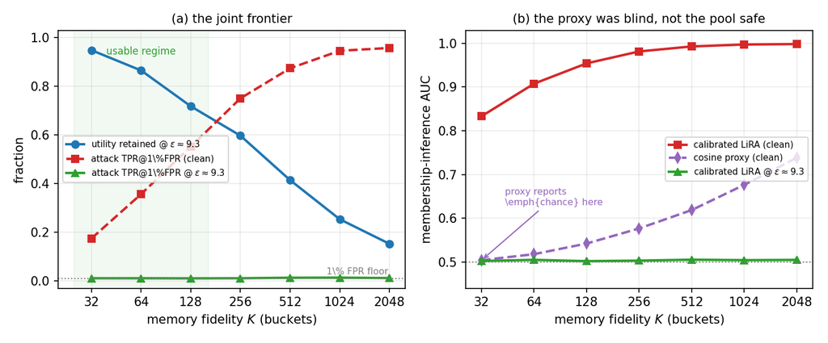

```
=== fig_utility_vs_eps ===
```

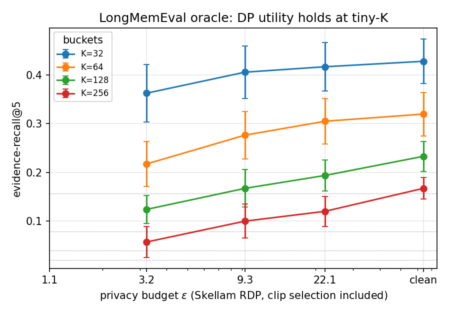

```
=== fig_leakage_drop ===
```

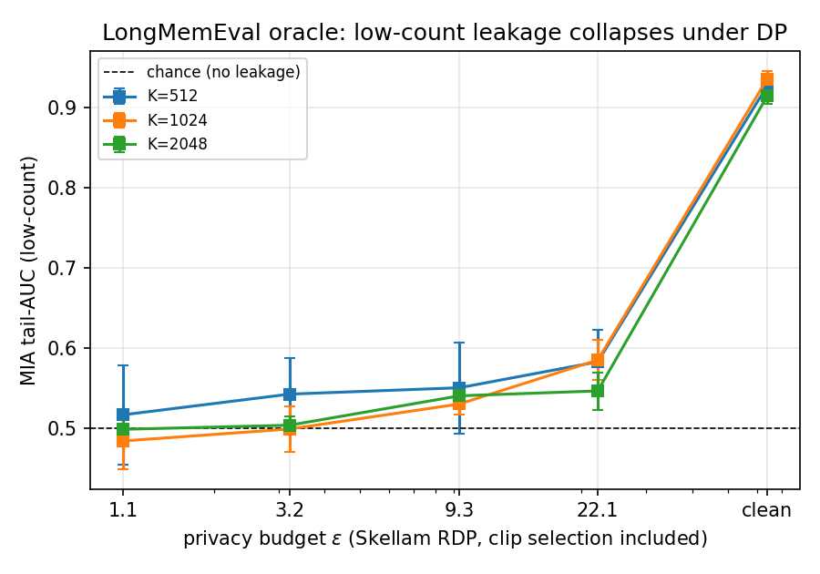

```
=== fig_projection_ablation ===
```

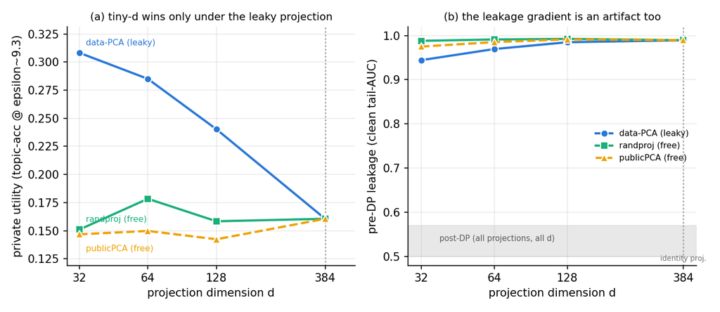

```
=== fig_distilled_utility ===
```

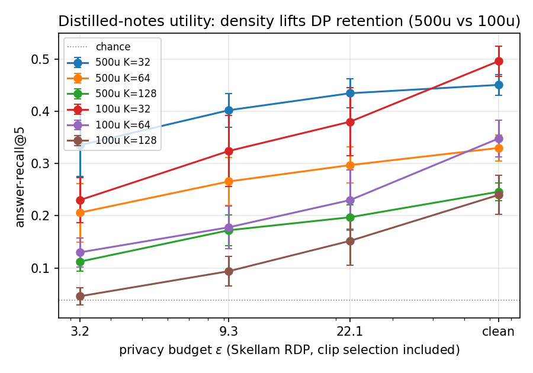

```
=== fig_distilled_leakage ===
```

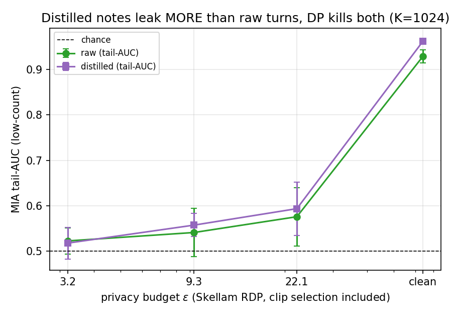